# Log

Joshua Tolhuis

9/14/2021

# EDA of Urinary Biomarkers for cancer

## Data

The data gained was from John Davis, uploaded to kaggle [John Davis](https://www.kaggle.com/johnjdavisiv/urinary-biomarkers-for-pancreatic-cancer). He had gotten his data from a paper with the title “A combination of urinary biomarker panel and PancRisk score for earlier detection of pancreatic caner: A case-control study”, this is the [link](https://journals.plos.org/plosmedicine/article?id=10.1371/journal.pmed.1003489) to the paper.

setup and load code book:

```r
codebook <- read.csv("Debernardi et al 2020 documentation.csv", sep = ",", header = T)

knitr::kable(codebook)
```

| Column.name | Original.column.name | Details |
| --- | --- | --- |
| sample_id | Sample ID | Unique string identifying each subject |
| patient_cohort | Patient’s Cohort | Cohort 1, previously used samples; Cohort 2, newly added samples |
| sample_origin | Sample Origin | BPTB: Barts Pancreas Tissue Bank, London, UK; ESP: Spanish National Cancer Research Centre, Madrid, Spain; LIV: Liverpool University, UK; UCL: University College London, UK |
| age | Age | Age in years |
| sex | Sex | M = male, F = female |
| diagnosis | Diagnosis (1=Control, 2=Benign, 3=PDAC) | 1 = control (no pancreatic disease), 2 = benign hepatobiliary disease (119 of which are chronic pancreatitis); 3 = Pancreatic ductal adenocarcinoma, i.e. pancreatic cancer |
| stage | Stage | For those with pancratic cancer, what stage was it? One of IA, IB, IIA, IIIB, III, IV |
| benign_sample_diagnosis | Benign Samples Diagnosis | For those with a benign, non-cancerous diagnosis, what was the diagnosis? |
| plasma_CA19_9 | Plasma CA19-9 U/ml | Blood plasma levels of CA 19–9 monoclonal antibody that is often elevated in patients with pancreatic cancer. Only assessed in 350 patients (one goal of the study was to compare various CA 19-9 cutpoi… |
| creatinine | Creatinine mg/ml | Urinary biomarker of kidney function |
| LYVE1 | LYVE1 ng/ml | Urinary levels of Lymphatic vessel endothelial hyaluronan receptor 1, a protein that may play a role in tumor metastasis |
| REG1B | REG1B ng/ml | Urinary levels of a protein that may be associated with pancreas regeneration. |
| TFF1 | TFF1 ng/ml | Urinary levels of Trefoil Factor 1, which may be related to regeneration and repair of the urinary tract |
| REG1A | REG1A ng/ml | Urinary levels of a protein that may be associated with pancreas regeneration. Only assessed in 306 patients (one goal of the study was to assess REG1B vs REG1A) |

Here is the corresponding data file and it’s first 6 entries:

```r
data <- read.csv("Debernardi et al 2020 data.csv", header = T, sep = ",")
knitr::kable(head(data))
```

| sample_id | patient_cohort | sample_origin | age | sex | diagnosis | stage | benign_sample_diagnosis | plasma_CA19_9 | creatinine | LYVE1 | REG1B | TFF1 | REG1A |
| --- | --- | --- | --- | --- | --- | --- | --- | --- | --- | --- | --- | --- | --- |
| S1 | Cohort1 | BPTB | 33 | F | 1 |  |  | 11.7 | 1.83222 | 0.8932192 | 52.94884 | 654.2822 | 1262.000 |
| S10 | Cohort1 | BPTB | 81 | F | 1 |  |  | NA | 0.97266 | 2.0375850 | 94.46703 | 209.4882 | 228.407 |
| S100 | Cohort2 | BPTB | 51 | M | 1 |  |  | 7.0 | 0.78039 | 0.1455889 | 102.36600 | 461.1410 | NA |
| S101 | Cohort2 | BPTB | 61 | M | 1 |  |  | 8.0 | 0.70122 | 0.0028049 | 60.57900 | 142.9500 | NA |
| S102 | Cohort2 | BPTB | 62 | M | 1 |  |  | 9.0 | 0.21489 | 0.0008596 | 65.54000 | 41.0880 | NA |
| S103 | Cohort2 | BPTB | 53 | M | 1 |  |  | NA | 0.84825 | 0.0033930 | 62.12600 | 59.7930 | NA |

Loading up libraries to be used in the EDA and log

```r
if(!require(devtools)) install.packages("devtools")
devtools::install_github("sinhrks/ggfortify")
devtools::install_github("AckerDWM/gg3D")
library("gg3D")
```

```r
library(ggplot2)
library(tidyr)
library(gridExtra)
library(dplyr)
library(plotly)
library(cluster)
library(ggfortify)
```

## Intro

At first, I wanted to know if REG1B could be used only to predict PDAC, but after reconsideration I want to find out what the minimum required data is to find out if a patient has PDAC. Even so i first wanted to run some tests on the newly improved biomarker REG1B to find out it’s impact, and it’s change relative to REG1A.

Let’s take a first look at the effect of REG1B stand alone, what conclusions can be made by looking at the markers found at different stages.

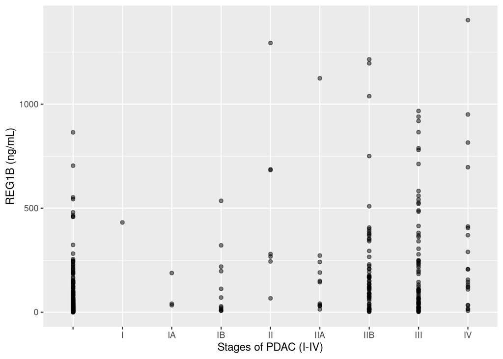

```r
ggplot(data = data, mapping = aes(x = stage, y = REG1B)) +
        geom_point(alpha = 0.5) +
        xlab("Stages of PDAC (I-IV)") +
        ylab("REG1B (ng/mL)")
```

In this plot becomes clear, that REG1B is has teh same values at the stages “0, IIB, III and IV” relative to the others. This rises the question with which other data values the results be improved so that stage 0 and I - IIA can be recognized more easily. Lets first try finding patterns using only bodily data such as, age, sex, and body fluids or hormones.

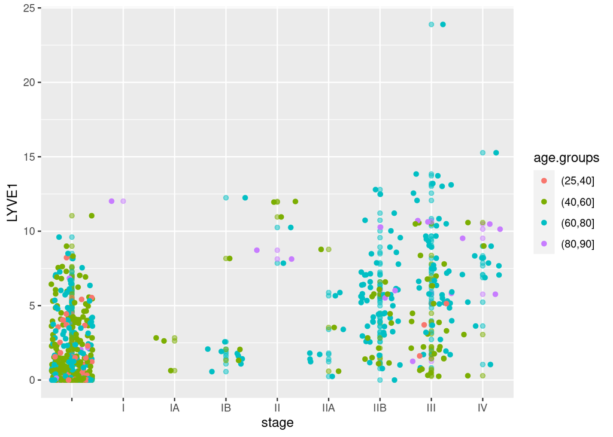

```r
age.groups <- cut(data$age, breaks = c(25 ,40, 60, 80, 90))
ggplot(data = data, mapping = aes(x = stage, y = LYVE1, col = age.groups)) +
        geom_point(alpha = 0.5) +
        geom_jitter()
```

```r
sum(data$age < 40)
```

```
## [1] 43
```

```r
sum(data$age < 40 & data$stage == "")
```

```
## [1] 40
```

But I found out that there were only 43 people under 40 in this data set and only 3 of them had a state assigned to them. So I concluded, age had no effect on the effects of this biomarker.

I also tried another few values as 3rd dimension to see if any would be promising:

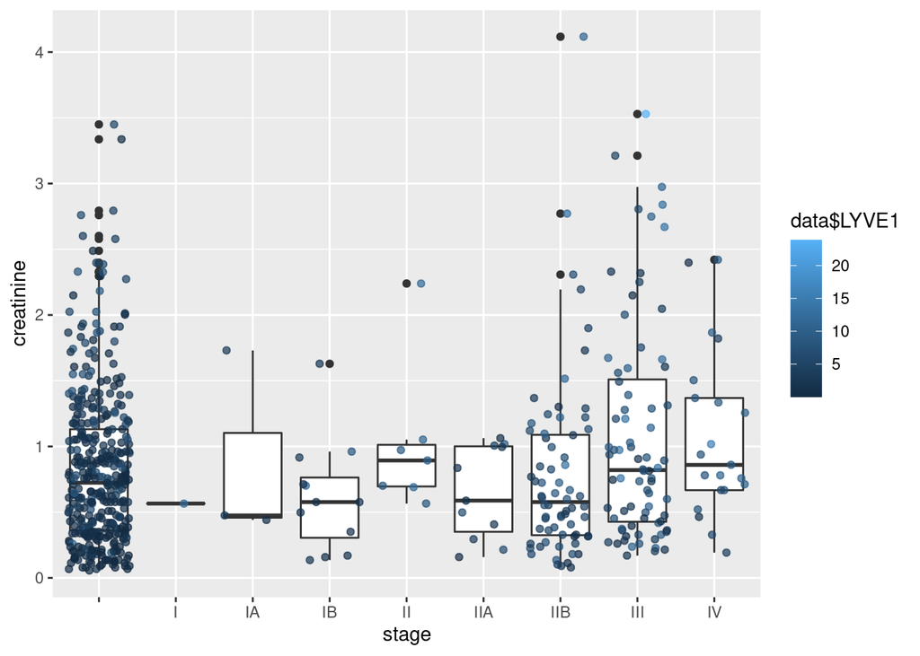

```r
creatinine.groups <- cut(data$creatinine, breaks = c(0.05654 ,1.071623 ,2.086695, 3.101768, 4.11685))
ggplot(data = data, mapping = aes(x = stage, y = creatinine)) +
        geom_boxplot() +
        geom_jitter(alpha = 0.7, aes(col = data$LYVE1))
```

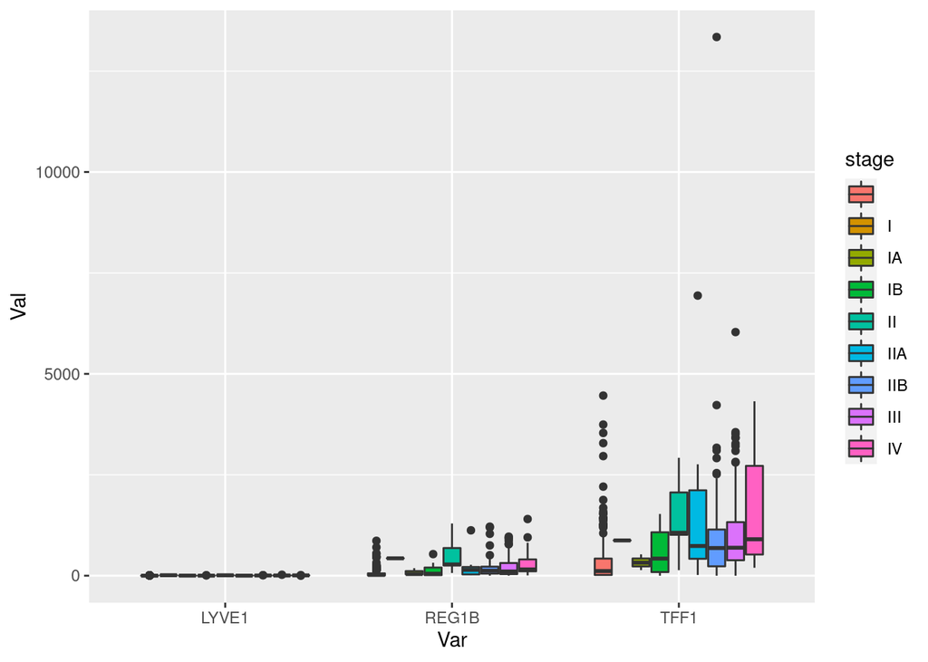

```r
data %>% select(REG1B, TFF1, LYVE1, stage) %>%
pivot_longer(., cols = c(REG1B,TFF1,LYVE1), names_to = "Var", values_to = "Val") %>%
        ggplot(aes(x = Var, y = Val, fill = stage)) +
        geom_boxplot()
```

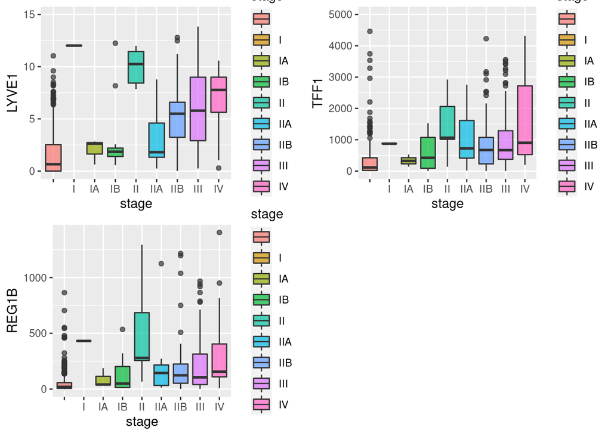

```r
p1 <- ggplot(data = data, mapping = aes(x = stage, y = LYVE1, fill = stage)) +
        geom_boxplot(alpha = 0.7) +
        ylim(0, 15)

p2 <- ggplot(data = data, mapping = aes(x = stage, y = TFF1, fill = stage)) +
        geom_boxplot(alpha = 0.7) +
        ylim(0, 5000)

p3 <- ggplot(data = data, mapping = aes(x = stage, y = REG1B, fill = stage)) +
        geom_boxplot(alpha = 0.7)

grid.arrange(p1, p2, p3, nrow = 2)
```

```r
scale_min_max <- function(x) {
     (x - min(x)) / (max(x) - min(x))
}

df <- as.data.frame(data[392:590,])
row.names(df) <- paste(df$stage, row.names(df), sep="_")

df[11:13]
```

```
##               LYVE1       REG1B         TFF1
## I_392   12.01715000  431.422530 8.740997e+02
## IA_393   2.62842500   40.620818 5.299840e+02
## IA_394   2.83054100   33.406150 3.231758e+02
## IA_395   0.63243260  188.253000 1.386300e+02
## IB_396  12.24582000  196.921830 1.529183e+03
## IB_397   2.56734600   15.695743 2.970097e+02
## IB_398   1.42287700    7.085142 4.499118e-02
## IB_399   2.08153500   22.244200 5.480474e+01
## IB_400   8.16755400  535.281600 1.099519e+03
## IB_401   1.78321200  112.348000 4.785100e+01
## IB_402   1.61933900    8.675667 6.108991e+02
## IB_403   1.92032700  219.129024 4.146139e+02
## IB_404   0.56583980  321.308160 1.068504e+03
## IB_405   1.08506400   70.605010 1.115292e+03
## IB_406   1.31914400   28.068943 1.024494e+02
## IB_407   2.05643800    8.432788 4.335330e+02
## II_408   7.84910500  267.856820 1.063949e+03
## II_409  11.95479000  682.898790 1.047710e+03
## II_410   8.72221200  243.906740 1.730613e+03
## II_411  10.95695000 1293.819450 2.921507e+03
## II_412  10.25015000  279.524840 9.778096e+02
## II_413   8.12974700   66.833074 1.383245e+02
## II_414  11.99636000  686.596400 2.395081e+03
## IIA_415  5.87575900  272.131400 2.759204e+03
## IIA_416  5.66198400   30.754640 3.967304e+02
## IIA_417  1.72242900   41.140085 4.079489e+02
## IIA_418  1.23380200  144.475310 1.803015e+03
## IIA_419  1.40685700   13.618654 4.317260e+02
## IIA_420  8.77698200  150.187310 1.050400e+03
## IIA_421  0.59247880   29.716092 7.109413e+02
## IIA_422  3.40208400  241.579240 2.428988e+03
## IIA_423  3.53085500 1124.108000 6.939098e+03
## IIA_424  0.24221000   34.981375 1.785104e+01
## IIA_425  1.80642200  190.812000 7.366730e+02
## IIB_426  2.55849100   15.176469 1.013080e+02
## IIB_427  8.57669400  115.915310 2.542312e+03
## IIB_428  7.78674100  222.366130 1.541649e+03
## IIB_429 12.48489000  349.068580 3.169306e+03
## IIB_430  2.58967400   88.393900 2.240890e+02
```

[output cut: 145 more lines]

```
## IV_576   3.62908700  119.243250 9.031260e+02
## IV_577   8.99246000 1403.897600 4.320489e+03
## IV_578   7.85949900   34.189659 3.735307e+02
## IV_579  15.27052000  132.879880 2.333089e+03
## IV_580   1.04434500   14.364360 3.273971e+02
## IV_581  10.57861000  206.526460 3.203940e+03
## IV_582   5.23252700  123.104730 7.558209e+02
## IV_583   0.28950000    6.824000 7.992560e+02
## IV_584   5.76434900  950.080000 1.945172e+03
## IV_585   7.08563700  815.136000 2.367590e+03
## IV_586   7.05820900  156.241000 5.251780e+02
## IV_587   8.34120700   16.915000 2.459470e+02
## IV_588   7.67470700  289.701000 5.372860e+02
## IV_589   8.20677700  205.930000 7.225230e+02
## IV_590   8.20095800  411.938275 2.021321e+03
```

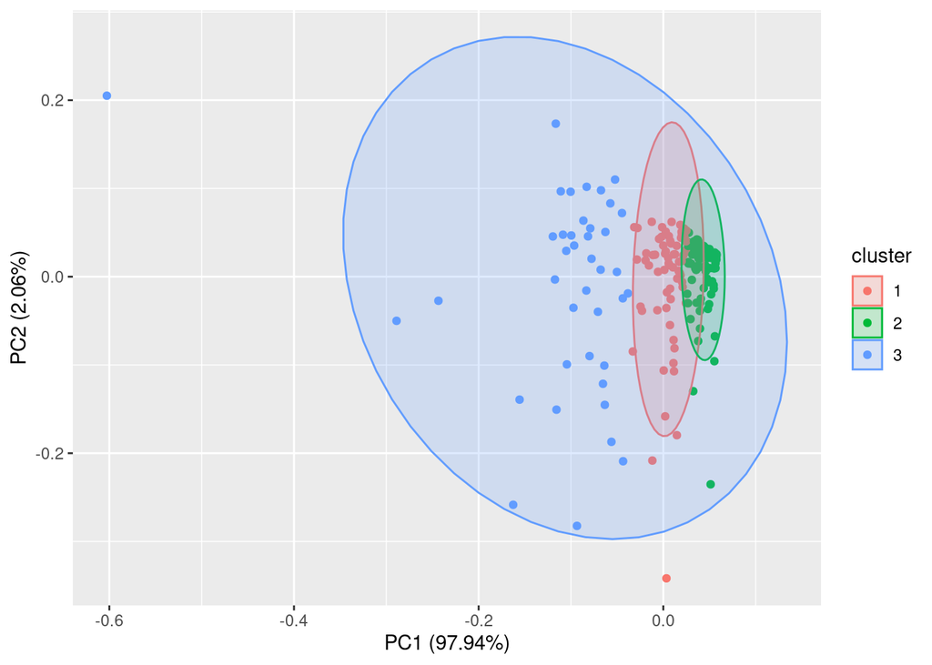

```r
autoplot(pam(df[c(8,11:13)], 3), frame = TRUE, frame.type = 'norm')
```

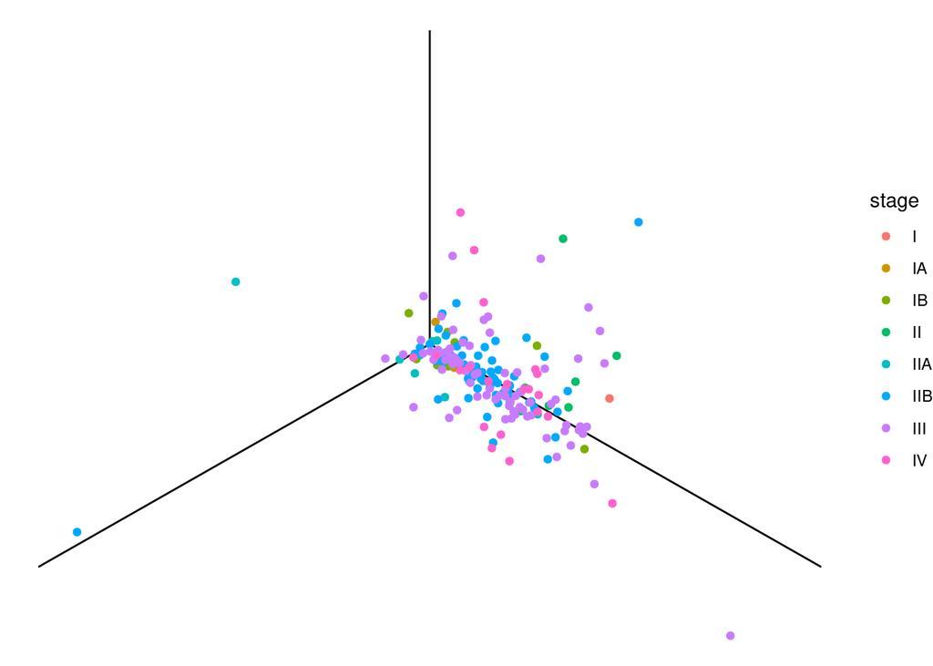

```r
ggplot(df, aes(x= scale_min_max(TFF1), y = scale_min_max(LYVE1), z = scale_min_max(REG1B), color= stage)) +
  theme_void() +
  axes_3D() +
  stat_3D() +
        xlab("TFF1")
```